# LCL fiber-seq data example

Crystal Shan

2026-10-30

This tutorial is based on real LCL data pooled from 31 samples.

## 1. Load the installed package and choose settings

Install the package and dependencies using its README before knitting. The tutorial itself does not install anything. It uses Rsamtools through the package to read tabix-indexed tracks; an external `tabix` executable is not needed.

```r
library(selectFiberseqLociWorkflow)
library(SummarizedExperiment)
library(GenomicRanges)
```

### Edit the YAML parameters before knitting

The YAML header is not displayed automatically in knitted HTML. The complete parameter block is reproduced here so HTML readers can see what to edit. Download or open `LCL-fiber-seq-data-example.Rmd`, edit its existing `params:` block between the opening `---` lines, save the Rmd, and knit it again. Editing the HTML will not change the analysis.

```yaml
params:
  gene: "ALAS1"
  flank_bp: 1000
  sample_sheet: "/project/spott/1_Shared_projects/LCL_Fiber_seq/Data/LCL_sample_metatable_merged_samples_31samples.csv"
  tss_bed: "/project/spott/cshan/annotations/gencodev46_Ensembl_canonical_TSS.bed"
  tf_root: "/project/spott/1_Shared_projects/LCL_Fiber_seq/FiberHMM/FiberHMM_v2/results/results_v1_trained_model"
  clustering: true
  window_size: 0
  k_neighbors: 10
  resolution: 1
  seed: 1
  nuc_min: 130
  nuc_max: 160
  min_tf_score: 50
  smoothing_bp: 10
  output_dir: null
```

Change `gene` to select another locus and update the three input paths for your files. YAML uses lowercase `true` and `false`: `clustering: false` runs only the unclustered analysis; `clustering: true` adds the clustered analysis. Set `output_dir` to a new or empty directory to retain results, or keep `null` to create a temporary directory. The bin width, neighbor count and resolution shown above are the current package defaults.

Alternatively, override these values with the `params` argument to `rmarkdown::render()` (R uses uppercase `TRUE`, `FALSE` and `NULL`). For example:

```r
rmarkdown::render("LCL-fiber-seq-data-example.Rmd",
    params = list(gene = "ALAS1", clustering = TRUE,
        window_size = 50, k_neighbors = 5, resolution = 0.5,
        output_dir = "LCL-ALAS1-custom-results"))
```

The following table records the settings actually used for this knitted run.

```r
gene <- params$gene
flank_bp <- params$flank_bp
knitr::kable(data.frame(
    setting = c("gene", "flank_bp", "clustering", "window_size",
        "k_neighbors", "resolution", "seed", "nuc_min", "nuc_max",
        "min_tf_score", "smoothing_bp"),
    value = vapply(params[c("gene", "flank_bp", "clustering", "window_size",
        "k_neighbors", "resolution", "seed", "nuc_min", "nuc_max",
        "min_tf_score", "smoothing_bp")], as.character, character(1))))
```

|  | setting | value |
| --- | --- | --- |
| gene | gene | ALAS1 |
| flank_bp | flank_bp | 1000 |
| clustering | clustering | TRUE |
| window_size | window_size | 0 |
| k_neighbors | k_neighbors | 10 |
| resolution | resolution | 1 |
| seed | seed | 1 |
| nuc_min | nuc_min | 130 |
| nuc_max | nuc_max | 160 |
| min_tf_score | min_tf_score | 50 |
| smoothing_bp | smoothing_bp | 10 |

```r
# With output_dir = NULL, write a new temporary result directory.
# Set output_dir to a new persistent directory when retaining an analysis.
run_dir <- if (is.null(params$output_dir)) {
    tempfile(paste0("LCL-", gene, "-"))
} else {
    path.expand(params$output_dir)
}
if (dir.exists(run_dir) &&
    length(list.files(run_dir, all.files = TRUE, no.. = TRUE))) {
    stop("Choose a new or empty output_dir to avoid replacing an earlier run")
}
dir.create(run_dir, recursive = TRUE, showWarnings = FALSE)
run_dir <- normalizePath(run_dir, mustWork = TRUE)
```

`window_size = 0` uses individual observed m6A sites for clustering. A positive integer, such as `50`, averages calls across observed sites in each occupied bin of that width in bp. `k_neighbors = 10` requests ten Manhattan nearest neighbors per read, capped at the number of reads minus one. `resolution = 1` is the Leiden resolution; larger values generally favor finer partitions. `smoothing_bp = 10` independently controls profile smoothing. The stored assay remains at single-base resolution for every bin width.

## 2. Convert the shared sample metadata to a package sample sheet

The original CSV contains many analysis columns. Only `sample_name` and `fire_dir` are needed here. The sample-sheet order is retained for plotting. The short sample label comes from the part before the first underscore.

```r
if (!file.exists(params$sample_sheet)) {
    stop("Shared sample metadata not found: ", params$sample_sheet)
}
sample_metadata <- read.csv(params$sample_sheet, stringsAsFactors = FALSE)
stopifnot(all(c("sample_name", "fire_dir") %in% names(sample_metadata)))
sample_metadata <- sample_metadata[, c("sample_name", "fire_dir")]
knitr::kable(head(sample_metadata, 3), row.names = FALSE)
```

| sample_name | fire_dir |
| --- | --- |
| AL6_bc2162_19093 | /project/spott/1_Shared_projects/LCL_Fiber_seq/FIRE/results/AL6_bc2162_19093 |
| AL8_bc2170_19151 | /project/spott/1_Shared_projects/LCL_Fiber_seq/FIRE/results/AL8_bc2170_19151 |
| AL10_bc2178_19130 | /project/spott/1_Shared_projects/LCL_Fiber_seq/FIRE/results/AL10_bc2178_19130 |

These are the same four processed track sources used in the original tutorial:

| Track | Location | Declared format |
| --- | --- | --- |
| m6A | `<fire_dir>/extracted_results/m6a_by_chr/<sample>.ft_extracted_m6a.<chr>.bed.gz` | `bed12_fibertools` |
| Nucleosome | `<fire_dir>/extracted_results/nuc_by_chr/<sample>.ft_extracted_nuc.<chr>.bed.gz` | `bed12_fibertools` |
| TF footprint | `<tf_root>/<sample>/<sample>.recalled_tf.bed.gz` | `bed15_fiberhmm_tf` |
| FIRE | `<fire_dir>/additional-outputs-v0.1/fire-peaks/<sample>-v0.1-fire-elements.bed.gz` | `bed11_fire` |

Each file needs its adjacent `.tbi` index. The format is explicit, not guessed from the caller name or filename. FIRE intervals are joined by read ID; legacy haplotype tags are not used for grouping. No phased or allele-specific input is needed.

```r
samples <- make_sample_sheet(data.frame(
    sample_name = sample_metadata$sample_name,
    sample_label = sub("_.*$", "", sample_metadata$sample_name),
    m6a = file.path(sample_metadata$fire_dir, "extracted_results", "m6a_by_chr",
        "{sample_name}.ft_extracted_m6a.{chr}.bed.gz"),
    m6a_format = "bed12_fibertools",
    nucleosome = file.path(sample_metadata$fire_dir, "extracted_results",
        "nuc_by_chr", "{sample_name}.ft_extracted_nuc.{chr}.bed.gz"),
    nucleosome_format = "bed12_fibertools",
    tf = file.path(params$tf_root, "{sample_name}",
        "{sample_name}.recalled_tf.bed.gz"),
    tf_format = "bed15_fiberhmm_tf",
    fire = file.path(sample_metadata$fire_dir, "additional-outputs-v0.1",
        "fire-peaks", "{sample_name}-v0.1-fire-elements.bed.gz"),
    fire_format = "bed11_fire"),
    output = file.path(run_dir, "samples.tsv"))

knitr::kable(as.data.frame(samples[, c("sample_name", "sample_label")]),
    row.names = FALSE)
```

| sample_name | sample_label |
| --- | --- |
| AL6_bc2162_19093 | AL6 |
| AL8_bc2170_19151 | AL8 |
| AL10_bc2178_19130 | AL10 |
| AL16_bc2114_18508 | AL16 |
| AL18_bc2130_18504 | AL18 |
| AL19_bc2138_18861 | AL19 |
| AL20_bc2146_19209 | AL20 |
| AL27_bc2155_18913 | AL27 |
| AL28_bc2163_19153 | AL28 |
| AL30_bc2179_18510 | AL30 |
| AL38_bc2125_18499 | AL38 |
| AL39_bc2133_19207 | AL39 |
| AL43_bc2149_18511 | AL43 |
| AL44_bc2157_19138 | AL44 |
| AL45_bc2110_19201 | AL45 |
| AL46_bc2118_19194 | AL46 |
| AL47_bc2126_19222 | AL47 |
| AL48_bc2134_18505 | AL48 |
| AL49_bc2142_19103 | AL49 |
| AL50_bc2111_18858 | AL50 |
| AL51_bc2119_19223 | AL51 |
| AL54_bc2143_19192 | AL54 |
| AL55_bc2112_19238 | AL55 |
| AL56_bc2120_18489 | AL56 |
| AL57_bc2128_19132 | AL57 |
| AL58_bc2136_19129 | AL58 |
| AL59_bc2144_19143 | AL59 |
| AL60_bc2152_18519 | AL60 |
| AL61_bc2160_18498 | AL61 |
| AL62_bc2168_19140 | AL62 |
| AL29AL40AL53_bc2171bc2141bc2132_18916 | AL29AL40AL53 |

This render selects **31 samples**. Omit an optional track’s path and format columns if that track is unavailable for your dataset. A supplied but nonexistent file is an input error, so optional tracks should not be represented by invented paths.

## 3. Prepare the same promoter window

The supplied TSS BED uses one-base BED intervals and names of the form `geneID;transcriptID;geneName;...`. The package’s `gencode_custom` reader selects the requested gene and expands its TSS. The source file is already canonical; ordinary GTF/GFF3 annotations are also supported and do not require canonical transcript tags.

```r
region <- prepare_regions(params$tss_bed,
    bed_annotation = "gencode_custom", genes = gene, flank_bp = flank_bp)
if (length(region) != 1L) {
    stop("This single-locus tutorial requires exactly one selected TSS")
}
names(region) <- gene
mcols(region)$region_id <- gene
region <- prepare_regions(region, output = file.path(run_dir, "regions.tsv"))
region
```

```
## GRanges object with 1 range and 5 metadata columns:
##         seqnames            ranges strand |   region_id          V5
##            <Rle>         <IRanges>  <Rle> | <character> <character>
##   ALAS1     chr3 52197160-52199159      + |       ALAS1           .
##                    gene_id   gene_name       tss
##                <character> <character> <numeric>
##   ALAS1 ENSG00000023330.15       ALAS1  52198160
##   -------
##   seqinfo: 1 sequence from an unspecified genome; no seqlengths
```

```r
knitr::kable(read.delim(file.path(run_dir, "regions.tsv")), row.names = FALSE)
```

| region_id | V5 | gene_id | gene_name | tss | chr | start | end | strand | analysis_start | analysis_end | width |
| --- | --- | --- | --- | --- | --- | --- | --- | --- | --- | --- | --- |
| ALAS1 | . | ENSG00000023330.15 | ALAS1 | 52198160 | chr3 | 52197159 | 52199159 | + | 52197160 | 52199159 | 2000 |

For ALAS1, the original TSS BED is `[52198159, 52198160)` on chr3. With 1,000-bp flanks, the selected BED window is `[52197159, 52199159)` and the R `GRanges` is **chr3:52197160-52199159**, with TSS **52198160**. BED starts are converted once; all in-memory coordinates are one-based inclusive.

To analyze PRDX1 instead, set `gene = "PRDX1"`. It is on the minus strand; the upstream side is to the right on a genomic-coordinate plot. Neither strand changes the convention that genomic start is less than genomic end.

## 4. Validate and extract the unclustered locus

```r
validate_inputs(samples, region)
unclustered_results <- analyze_loci(samples, region, clustering = FALSE,
    nuc_min = params$nuc_min, nuc_max = params$nuc_max,
    min_tf_score = params$min_tf_score, smoothing_bp = params$smoothing_bp)
x <- unclustered_results[[gene]]
x
```

```
## class: RangedSummarizedExperiment
## dim: 2000 534
## metadata(7): region samples ... empty_footprint_tracks package_version
## assays(1): m6a
## rownames(2000): chr3:52197160 chr3:52197161 ... chr3:52199158
##   chr3:52199159
## rowData names(0):
## colnames(534): AL6_bc2162_19093::m84241_250514_222554_s2/132252921/ccs
##   AL6_bc2162_19093::m84241_250514_222554_s2/265817825/ccs ...
##   AL29AL40AL53_bc2171bc2141bc2132_18916::m84241_250907_054529_s2/147132078/ccs
##   AL29AL40AL53_bc2171bc2141bc2132_18916::m84241_250908_200356_s4/207030672/ccs
## colData names(11): RID original_RID ... read_range footprints
```

The returned assay is a sparse **positions-by-reads** matrix, the transpose of the original tutorial’s read-by-position matrix. The package removes fibertools sentinel blocks, considers each read’s longest overlapping alignment, and retains it only when it spans the entire window. Reads with no m6A calls in the window remain in the assay and profile denominators.

```r
qc <- as.data.frame(metadata(x)$qc)
zero_call <- Matrix::colSums(assay(x, "m6a")) == 0
zero_by_sample <- table(factor(colData(x)$sample_name[zero_call],
    levels = samples$sample_name))
qc$zero_m6a_reads <- as.integer(zero_by_sample[qc$sample_name])
knitr::kable(qc, row.names = FALSE)
```

| sample_name | overlapping_reads | full_span_reads | zero_m6a_reads |
| --- | --- | --- | --- |
| AL6_bc2162_19093 | 10 | 8 | 0 |
| AL8_bc2170_19151 | 13 | 10 | 0 |
| AL10_bc2178_19130 | 21 | 15 | 0 |
| AL16_bc2114_18508 | 15 | 10 | 0 |
| AL18_bc2130_18504 | 12 | 6 | 0 |
| AL19_bc2138_18861 | 13 | 11 | 0 |
| AL20_bc2146_19209 | 38 | 30 | 0 |
| AL27_bc2155_18913 | 8 | 7 | 0 |
| AL28_bc2163_19153 | 24 | 17 | 0 |
| AL30_bc2179_18510 | 25 | 19 | 0 |
| AL38_bc2125_18499 | 19 | 15 | 0 |
| AL39_bc2133_19207 | 14 | 9 | 0 |
| AL43_bc2149_18511 | 11 | 11 | 0 |
| AL44_bc2157_19138 | 21 | 15 | 0 |
| AL45_bc2110_19201 | 32 | 24 | 0 |
| AL46_bc2118_19194 | 15 | 12 | 0 |
| AL47_bc2126_19222 | 20 | 17 | 0 |
| AL48_bc2134_18505 | 26 | 17 | 0 |
| AL49_bc2142_19103 | 21 | 18 | 0 |
| AL50_bc2111_18858 | 21 | 17 | 0 |
| AL51_bc2119_19223 | 35 | 23 | 0 |
| AL54_bc2143_19192 | 35 | 22 | 0 |
| AL55_bc2112_19238 | 18 | 14 | 0 |
| AL56_bc2120_18489 | 21 | 11 | 0 |
| AL57_bc2128_19132 | 51 | 40 | 0 |
| AL58_bc2136_19129 | 44 | 31 | 0 |
| AL59_bc2144_19143 | 21 | 18 | 0 |
| AL60_bc2152_18519 | 26 | 17 | 0 |
| AL61_bc2160_18498 | 19 | 17 | 0 |
| AL62_bc2168_19140 | 14 | 10 | 0 |
| AL29AL40AL53_bc2171bc2141bc2132_18916 | 54 | 43 | 0 |

```r
knitr::kable(data.frame(samples_in_sheet = nrow(samples),
    samples_with_full_span_reads = sum(qc$full_span_reads > 0L),
    genomic_bases = nrow(x), full_span_reads = ncol(x),
    zero_m6a_reads = sum(zero_call), m6a_calls = sum(assay(x, "m6a"))))
```

| samples_in_sheet | samples_with_full_span_reads | genomic_bases | full_span_reads | zero_m6a_reads | m6a_calls |
| --- | --- | --- | --- | --- | --- |
| 31 | 31 | 2000 | 534 | 0 | 55073 |

### Keep genomic ranges and read metadata aligned

```r
rowRanges(x)[1:3]
```

```
## GRanges object with 3 ranges and 0 metadata columns:
##                 seqnames    ranges strand
##                    <Rle> <IRanges>  <Rle>
##   chr3:52197160     chr3  52197160      *
##   chr3:52197161     chr3  52197161      *
##   chr3:52197162     chr3  52197162      *
##   -------
##   seqinfo: 1 sequence from an unspecified genome; no seqlengths
```

```r
colData(x)[1:3, c("sample_name", "original_RID", "start", "end")]
```

```
## DataFrame with 3 rows and 4 columns
##                                                              sample_name
##                                                              <character>
## AL6_bc2162_19093::m84241_250514_222554_s2/132252921/ccs AL6_bc2162_19093
## AL6_bc2162_19093::m84241_250514_222554_s2/265817825/ccs AL6_bc2162_19093
## AL6_bc2162_19093::m84241_241120_172940_s3/100664448/ccs AL6_bc2162_19093
##                                                                   original_RID
##                                                                    <character>
## AL6_bc2162_19093::m84241_250514_222554_s2/132252921/ccs m84241_250514_222554..
## AL6_bc2162_19093::m84241_250514_222554_s2/265817825/ccs m84241_250514_222554..
## AL6_bc2162_19093::m84241_241120_172940_s3/100664448/ccs m84241_241120_172940..
##                                                             start       end
##                                                         <integer> <integer>
## AL6_bc2162_19093::m84241_250514_222554_s2/132252921/ccs  52193358  52207176
## AL6_bc2162_19093::m84241_250514_222554_s2/265817825/ccs  52193478  52200906
## AL6_bc2162_19093::m84241_241120_172940_s3/100664448/ccs  52194577  52203172
```

```r
colData(x)$read_range[1:3]
```

```
## GRanges object with 3 ranges and 0 metadata columns:
##       seqnames            ranges strand
##          <Rle>         <IRanges>  <Rle>
##   [1]     chr3 52193358-52207176      +
##   [2]     chr3 52193478-52200906      +
##   [3]     chr3 52194577-52203172      -
##   -------
##   seqinfo: 1 sequence from an unspecified genome; no seqlengths
```

```r
colData(x)$footprints[1]
```

```
## GRangesList object of length 1:
## $`AL6_bc2162_19093::m84241_250514_222554_s2/132252921/ccs`
## GRanges object with 10 ranges and 3 metadata columns:
##        seqnames            ranges strand |                    RID       track
##           <Rle>         <IRanges>  <Rle> |            <character> <character>
##    [1]     chr3 52197131-52197272      * | AL6_bc2162_19093::m8..  nucleosome
##    [2]     chr3 52197291-52197426      * | AL6_bc2162_19093::m8..  nucleosome
##    [3]     chr3 52197638-52197775      * | AL6_bc2162_19093::m8..  nucleosome
##    [4]     chr3 52197777-52197916      * | AL6_bc2162_19093::m8..  nucleosome
##    [5]     chr3 52198881-52199026      * | AL6_bc2162_19093::m8..  nucleosome
##    [6]     chr3 52199096-52199241      * | AL6_bc2162_19093::m8..  nucleosome
##    [7]     chr3 52197977-52197992      * | AL6_bc2162_19093::m8..          tf
##    [8]     chr3 52198832-52198851      * | AL6_bc2162_19093::m8..          tf
##    [9]     chr3 52199055-52199077      * | AL6_bc2162_19093::m8..          tf
##   [10]     chr3 52197917-52198167      * | AL6_bc2162_19093::m8..        fire
##                        class
##                  <character>
##    [1] 130-160 bp nucleosome
##    [2] 130-160 bp nucleosome
##    [3] 130-160 bp nucleosome
##    [4] 130-160 bp nucleosome
##    [5] 130-160 bp nucleosome
##    [6] 130-160 bp nucleosome
##    [7]             size10-30
##    [8]             size10-30
##    [9]             size10-30
##   [10]                  fire
##   -------
##   seqinfo: 1 sequence from an unspecified genome; no seqlengths
```

```r
stopifnot(identical(names(rowRanges(x)), rownames(x)),
    identical(rownames(colData(x)), colnames(x)),
    identical(colData(x)$RID, colnames(x)),
    all(start(colData(x)$read_range) == colData(x)$start),
    all(end(colData(x)$read_range) == colData(x)$end))
```

Each assay column is named `sample_name::original_RID`. `colData$read_range` contains its alignment as a `GRanges`; `colData$footprints` is a `GRangesList` with one element per read. Standard experiment subsetting keeps these aligned. Metadata retain original QC and parameters as run provenance; `locus_profile()` recomputes fractions for the currently selected columns.

## 5. Unclustered m6A heatmap

Reads are shown vertically in sample-sheet order, then alignment start and read ID; positions are shown horizontally. Black denotes an observed m6A call. A zero is an absence of an observed call, not a measurement that every genomic base is an unmethylated adenine. The sample annotation is farthest left, followed by the cluster annotation in clustered views. The original tutorial’s coordinate ticks and orange dashed TSS marker are retained.

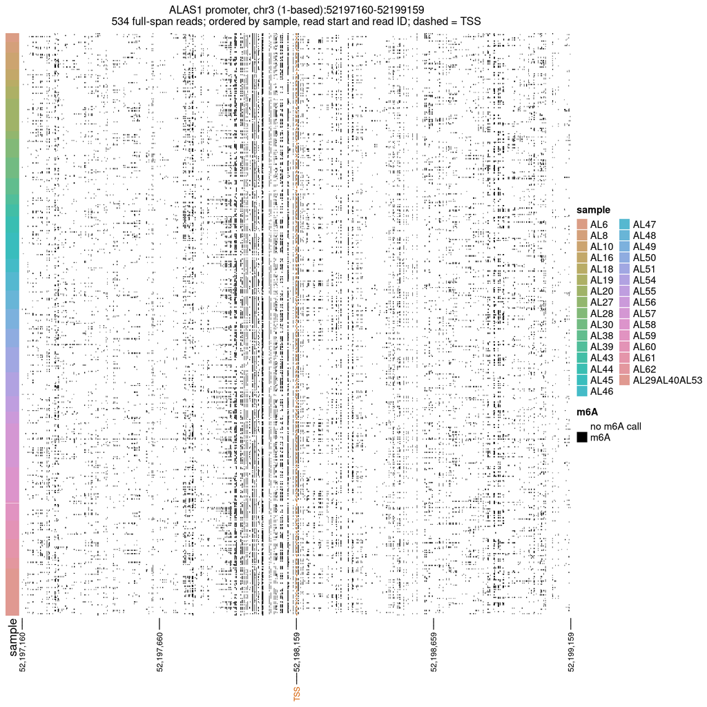

```r
ComplexHeatmap::draw(plot_locus(x, "heatmap"))
```

## 6. Pooled accessibility profile

Every full-span read, including zero-call reads, contributes to the denominator. The grey curve shows the fraction at observed positions; the blue curve is the sliding-window mean. The dashed line marks the supplied TSS.

```r
profile <- locus_profile(x)
head(profile)
```

```
## DataFrame with 6 rows and 8 columns
##         pos        base       group       cov       met       frac smooth_cov
##   <integer> <character> <character> <integer> <numeric>  <numeric>  <integer>
## 1  52197160           A         All       534         2 0.00374532        534
## 2  52197161           A         All       534        14 0.02621723        534
## 3  52197164           A         All       534         3 0.00561798        534
## 4  52197165           A         All       534         4 0.00749064        534
## 5  52197166           A         All       534         7 0.01310861        534
## 6  52197167           A         All       534         3 0.00561798        534
##   smooth_frac
##     <numeric>
## 1   0.0107678
## 2   0.0112360
## 3   0.0102996
## 4   0.0102996
## 5   0.0230961
## 6   0.0224719
```

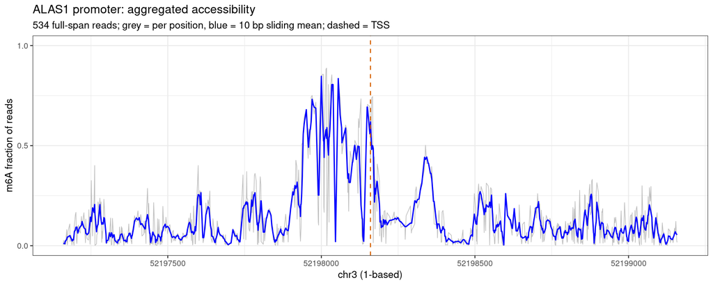

```r
stopifnot(all(profile$cov == ncol(x)))
plot_locus(x, "profile")
```

`locus_profile()` uses observed-call positions, as in the original tutorial. An all-zero locus returns zero fractions at all bases; a locus with no full-span reads returns `NA` fractions.

## 7. Matching footprint and FIRE tracks

The same retained reads are used for every panel. Defaults keep nucleosomes of 130-160 bp inclusive, TF block scores of at least 50, and TF width classes [10,30), [40,60) and [60,80) bp by default. To select other lengths, pass `tf_length_ranges = list(c(30, 39), c(80, 120))` (inclusive bounds) or `tf_length_ranges = NULL` (all lengths) to both `analyze_loci()` calls. Footprint coordinates stay one-based in R; calls overlapping a locus boundary retain their original interval bounds.

```r
footprints <- unlist(colData(x)$footprints, use.names = FALSE)
if (length(footprints)) {
    counts <- as.data.frame(table(track = mcols(footprints)$track,
        class = mcols(footprints)$class))
    knitr::kable(counts[counts$Freq > 0L, ], row.names = FALSE)
}
```

| track | class | Freq |
| --- | --- | --- |
| nucleosome | 130-160 bp nucleosome | 2723 |
| fire | fire | 647 |
| tf | size10-30 | 811 |
| tf | size40-60 | 156 |
| tf | size60-80 | 47 |

```r
metadata(x)$empty_footprint_tracks
```

```
## character(0)
```

A supplied nucleosome or TF track with no retained calls across the samples raises `no footprints called in the selected region`. The analysis continues and records the empty track type. Omitting optional tracks does not raise this warning.

The figure uses the original 2:6:6 layout: accessibility profile, blue m6A reads, and overlaid FIRE/nucleosome/TF tracks. FIRE is orange; nucleosomes are dark blue; the TF classes are purple, magenta and cyan. Read panels have sample-first annotation strips and matching read order. Genomic intervals are clipped only for drawing; the stored `GRanges` retain their bounds.

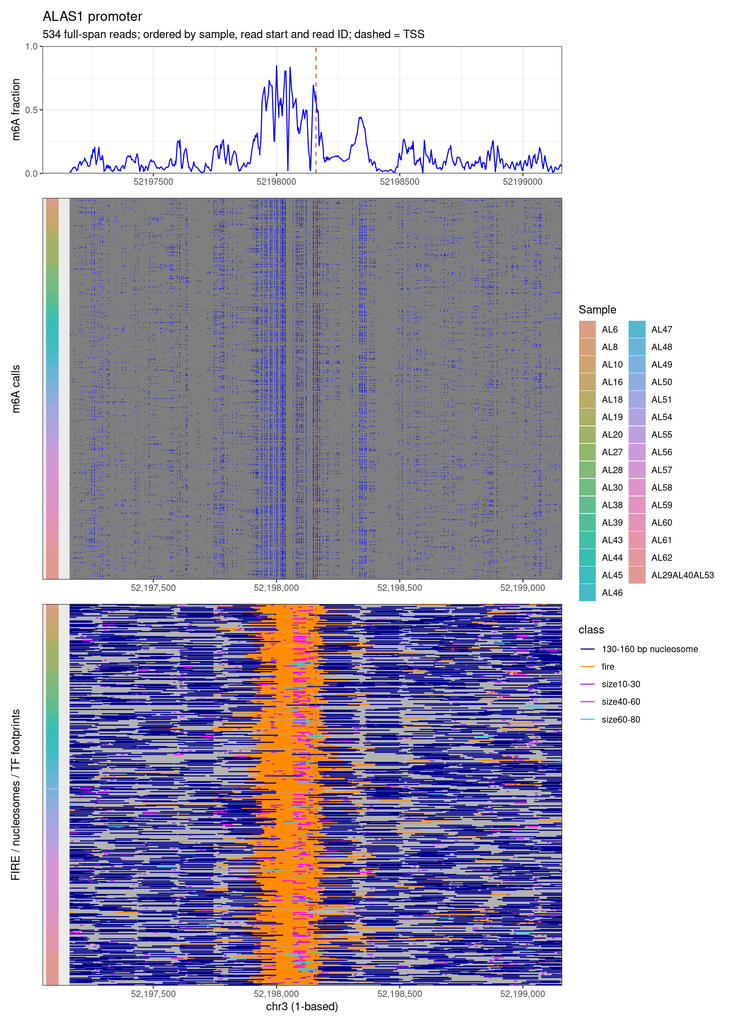

```r
plot_locus(x, "footprints")
```

## 8. Optional clustering of the same reads

Set the tutorial parameter `clustering = TRUE` to execute this additional analysis. It uses the bin size, nearest-neighbor count, resolution and seed specified at the start. Exact Manhattan distances use memory quadratic in the number of reads; inspect the locus’s read count before applying this to much larger datasets.

```r
clustered_results <- NULL
clustered_available <- FALSE
if (isTRUE(params$clustering)) {
    clustered_results <- analyze_loci(samples, region, clustering = TRUE,
        window_size = params$window_size, k_neighbors = params$k_neighbors,
        resolution = params$resolution, seed = params$seed,
        nuc_min = params$nuc_min, nuc_max = params$nuc_max,
        min_tf_score = params$min_tf_score, smoothing_bp = params$smoothing_bp)
    clustered <- clustered_results[[gene]]
    stopifnot(identical(assay(x), assay(clustered)),
        identical(colnames(x), colnames(clustered)),
        identical(locus_profile(x), locus_profile(clustered)))
    print(metadata(clustered)$parameters)
    print(metadata(clustered)$clustering_status)
    clustered_available <- "cluster" %in% names(colData(clustered))
    if (clustered_available) {
        print(table(colData(clustered)$sample_label, colData(clustered)$cluster))
        print(head(locus_profile(clustered, by_cluster = TRUE)))
    }
} else {
    cat("Clustering disabled: only the unclustered analysis was run.\n")
}
```

```
## $clustering
## [1] TRUE
##
## $window_size
## [1] 0
##
## $k_neighbors
## [1] 10
##
## $resolution
## [1] 1
##
## $seed
## [1] 1
##
## $nuc_min
## [1] 130
##
## $nuc_max
## [1] 160
##
## $min_tf_score
## [1] 50
##
## $smoothing_bp
## [1] 10
##
## [1] "complete"
##
##                cluster1 cluster2 cluster3 cluster4 cluster5 cluster6
##   AL10                3        3        6        3        0        0
##   AL16                4        3        2        0        1        0
##   AL18                2        0        0        2        1        1
##   AL19                4        2        1        3        0        1
##   AL20               10        2       12        5        0        1
##   AL27                2        2        2        0        1        0
##   AL28                4        8        2        1        1        1
##   AL29AL40AL53       12        8        6        8        5        4
##   AL30                6        4        3        4        0        2
##   AL38                3        8        2        1        1        0
```

[output cut: 23 more lines]

```
##   <integer> <character> <character> <integer> <numeric>  <numeric>  <integer>
## 1  52197160           A    cluster1       137         0 0.00000000        137
## 2  52197161           A    cluster1       137         7 0.05109489        137
## 3  52197164           A    cluster1       137         1 0.00729927        137
## 4  52197165           A    cluster1       137         2 0.01459854        137
## 5  52197166           A    cluster1       137         0 0.00000000        137
## 6  52197167           A    cluster1       137         1 0.00729927        137
##   smooth_frac
##     <numeric>
## 1   0.0182482
## 2   0.0145985
## 3   0.0133820
## 4   0.0133820
## 5   0.0279805
## 6   0.0233577
```

Cluster labels are stored in `colData`; the stored assay and its read order stay unchanged. Cluster plots order reads by cluster, sample, start and RID, and profiles use each cluster’s own denominator. Clustering requires at least three reads and two occupied features; otherwise the reason for skipping it is stored in `metadata`.

Clustered panels use the original Leiden palette throughout. To reuse those colors in your own plots:

```r
if (clustered_available) {
    cluster_colors(colData(clustered)$cluster)
}
```

```
##      cluster1      cluster2      cluster3      cluster4      cluster5
## "dodgerblue2"     "#E31A1C"      "green4"     "#6A3D9A"     "#FF7F00"
##      cluster6
##       "black"
```

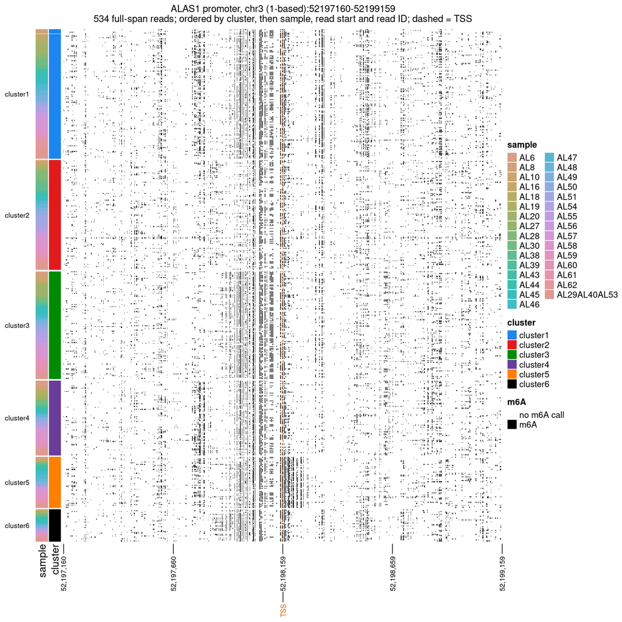

```r
if (clustered_available) {
    ComplexHeatmap::draw(plot_locus(clustered, "heatmap", clustered = TRUE))
}
```

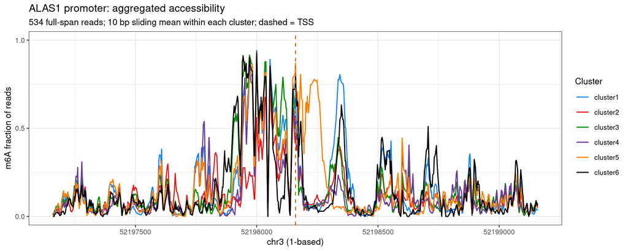

```r
if (clustered_available) {
    print(plot_locus(clustered, "profile", clustered = TRUE))
}
```

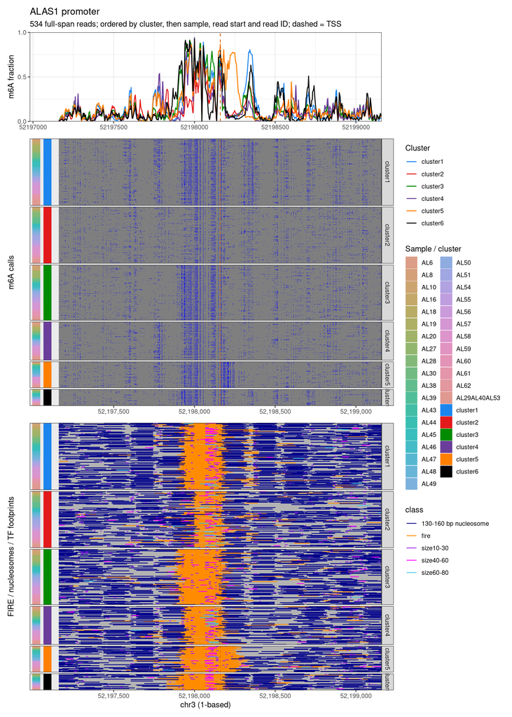

```r
if (clustered_available) {
    print(plot_locus(clustered, "footprints", clustered = TRUE))
}
```

## 9. Export and reload the Bioconductor result

```r
write_locus_results(unclustered_results,
    file.path(run_dir, "without-clustering"))
if (!is.null(clustered_results)) {
    write_locus_results(clustered_results,
        file.path(run_dir, "with-clustering"))
}
list.files(run_dir, recursive = TRUE)
```

```
##  [1] "regions.tsv"
##  [2] "samples.tsv"
##  [3] "with-clustering/ALAS1/clustered/accessibility_profile.tsv"
##  [4] "with-clustering/ALAS1/clustered/aggregate_m6a_profile.pdf"
##  [5] "with-clustering/ALAS1/clustered/assignments.tsv"
##  [6] "with-clustering/ALAS1/clustered/edges.tsv"
##  [7] "with-clustering/ALAS1/clustered/footprint_tracks.pdf"
##  [8] "with-clustering/ALAS1/clustered/m6a_heatmap.pdf"
##  [9] "with-clustering/ALAS1/clustered/manifest.tsv"
## [10] "with-clustering/ALAS1/clustered/read_order.tsv"
## [11] "with-clustering/ALAS1/locus.rds"
## [12] "with-clustering/ALAS1/m6a_matrix.rds"
## [13] "with-clustering/ALAS1/qc.tsv"
## [14] "with-clustering/ALAS1/reads.tsv"
## [15] "with-clustering/ALAS1/region.tsv"
```

[output cut: 17 more lines]

```r
restored <- readRDS(file.path(run_dir, "without-clustering", gene, "locus.rds"))
stopifnot(identical(assay(restored), assay(x)),
    identical(rowRanges(restored), rowRanges(x)),
    identical(colData(restored), colData(x)))
```

Each locus directory contains the complete `locus.rds`, sparse `m6a_matrix.rds`, read metadata, region table and QC. Its `unclustered/` directory contains PDF panels, profile/read-order TSVs and a panel manifest. After successful clustering, `clustered/` contains the corresponding views, `assignments.tsv` and `edges.tsv`. The clustered run also retains unclustered views. `samples.tsv` and `regions.tsv` at the run root document the inputs.

For repeat analyses, choose a new output directory. The shared input files and their indexes are only read.

## Re-run with another locus or clustering settings

Run these commands in R from the directory containing this Rmd. They are shown without execution so knitting does not start another render recursively. PRDX1 uses the same 31 sample paths with `{chr}` expanded to chr1.

```r
rmarkdown::render("LCL-fiber-seq-data-example.Rmd",
    output_file = "PRDX1-unclustered.html",
    params = list(gene = "PRDX1", clustering = FALSE,
        output_dir = "../results/PRDX1-unclustered"))

rmarkdown::render("LCL-fiber-seq-data-example.Rmd",
    output_file = "ALAS1-binned-clustering.html",
    params = list(gene = "ALAS1", clustering = TRUE,
        window_size = 50, k_neighbors = 5, resolution = 0.5,
        output_dir = "../results/ALAS1-binned-clustering"))
```

The persistent output directories in these examples must be new or empty. These paths are relative to the Rmd directory and continue to work after moving the containing project folder. The shared-data input paths are supplied through parameters and remain independent of the package checkout location.